# R Notebook

```r
library(tidyverse)
poetic <- read.csv("poetic.csv")
poetic <- poetic[, c(5, 3, 11, 4, 2, 10, 6, 8, 7, 9)]
# 5267 poems
no_rhymes <- poetic[poetic$rhymes == 0, ]
str(no_rhymes)
```

```
'data.frame':   21 obs. of  10 variables:
 $ poem_id           : int  226 319 725 726 728 733 2338 2441 2556 2687 ...
 $ century           : Factor w/ 2 levels "xix","xx": 1 1 1 1 1 1 2 2 2 2 ...
 $ words             : int  784 29 60 70 134 64 124 102 32 43 ...
 $ nouns             : int  176 8 15 22 38 16 28 18 11 9 ...
 $ adjectives        : int  30 1 4 3 4 4 7 11 0 10 ...
 $ verbs             : int  87 3 2 9 20 4 15 12 3 3 ...
 $ rhymes            : int  0 0 0 0 0 0 0 0 0 0 ...
 $ rhyming_nouns     : int  0 0 0 0 0 0 0 0 0 0 ...
 $ rhyming_adjectives: int  0 0 0 0 0 0 0 0 0 0 ...
 $ rhyming_verbs     : int  0 0 0 0 0 0 0 0 0 0 ...
```

```r
# 21 poems with no rhymes
poetic <- poetic[poetic$rhymes > 0, ]
str(poetic)
```

```
'data.frame':   5246 obs. of  10 variables:
 $ poem_id           : int  0 1 2 3 4 5 6 7 8 9 ...
 $ century           : Factor w/ 2 levels "xix","xx": 1 1 1 1 1 1 1 1 1 1 ...
 $ words             : int  369 116 110 625 201 70 115 57 140 304 ...
 $ nouns             : int  94 30 27 151 42 13 38 21 46 80 ...
 $ adjectives        : int  24 10 9 39 9 3 8 6 16 21 ...
 $ verbs             : int  52 8 9 97 24 12 18 6 16 38 ...
 $ rhymes            : int  50 16 16 114 28 12 18 8 24 48 ...
 $ rhyming_nouns     : int  24 9 7 47 14 8 11 6 20 26 ...
 $ rhyming_adjectives: int  6 1 0 6 2 1 1 1 0 10 ...
 $ rhyming_verbs     : int  12 2 3 36 6 2 4 0 3 6 ...
```

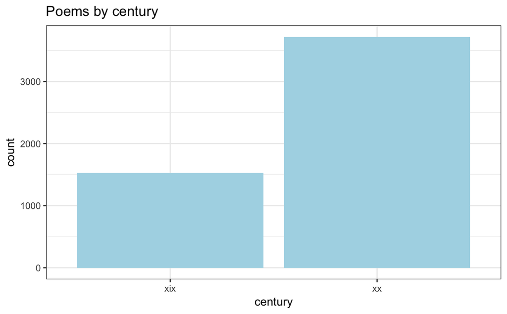

```r
#Let's have a look
poetic %>%
  ggplot(aes(century)) +
  geom_bar(fill = "lightblue") +
  labs(title = "Poems by century") +
  theme_bw()
```

Let’s make them even

```r
xx_cent <- poetic[poetic$century == "xx", ]
xix_cent <- poetic[poetic$century == "xix", ]
str(xx_cent)
```

```
'data.frame':   3718 obs. of  10 variables:
 $ poem_id           : int  1534 1535 1536 1537 1538 1539 1540 1541 1542 1543 ...
 $ century           : Factor w/ 2 levels "xix","xx": 2 2 2 2 2 2 2 2 2 2 ...
 $ words             : int  152 97 72 360 129 83 84 82 100 99 ...
 $ nouns             : int  36 22 26 78 28 25 17 13 17 30 ...
 $ adjectives        : int  11 6 3 13 4 7 2 11 7 7 ...
 $ verbs             : int  18 16 5 58 21 10 16 11 10 14 ...
 $ rhymes            : int  18 14 18 72 20 12 16 14 14 16 ...
 $ rhyming_nouns     : int  11 10 12 29 10 7 6 4 4 12 ...
 $ rhyming_adjectives: int  0 0 1 9 0 1 1 4 2 1 ...
 $ rhyming_verbs     : int  4 2 3 23 5 3 8 4 3 2 ...
```

```r
# Now there are 5246 poems
# Including 1528 XIX century poems and 3718 XX century poems
set.seed(42)
xx_cent_short <- sample_n(xx_cent, 1528)
poems <- rbind(xix_cent, xx_cent_short)
head(poems)
```

|  | poem_id | century | words | nouns | adjectives | verbs | rhymes | rhyming_nouns | rhyming_adjectives | rhyming_verbs |
| --- | --- | --- | --- | --- | --- | --- | --- | --- | --- | --- |
| 1 | 0 | xix | 369 | 94 | 24 | 52 | 50 | 24 | 6 | 12 |
| 2 | 1 | xix | 116 | 30 | 10 | 8 | 16 | 9 | 1 | 2 |
| 3 | 2 | xix | 110 | 27 | 9 | 9 | 16 | 7 | 0 | 3 |
| 4 | 3 | xix | 625 | 151 | 39 | 97 | 114 | 47 | 6 | 36 |
| 5 | 4 | xix | 201 | 42 | 9 | 24 | 28 | 14 | 2 | 6 |
| 6 | 5 | xix | 70 | 13 | 3 | 12 | 12 | 8 | 1 | 2 |

Let’s some new columns that we’ll need later: - average number of words per line in a poem, - percentage of verbs in a poem, - percentage of verbs in rhyming zones in a poem.

```r
poems$words_per_line <- round(poems$words / poems$rhymes, 2)
poems$percentage_verbs <- round(poems$verbs / poems$words, 2)
poems$percentage_rhyming_verbs <- round(poems$rhyming_verbs / poems$rhymes, 2)
head(poems)
```

|  | poem_id | century | words | nouns | adjectives | verbs | rhymes | rhyming_nouns | rhyming_adjectives | rhyming_verbs | words_per_line | percentage_verbs | percentage_rhyming_verbs |
| --- | --- | --- | --- | --- | --- | --- | --- | --- | --- | --- | --- | --- | --- |
| 1 | 0 | xix | 369 | 94 | 24 | 52 | 50 | 24 | 6 | 12 | 7.38 | 0.14 | 0.24 |
| 2 | 1 | xix | 116 | 30 | 10 | 8 | 16 | 9 | 1 | 2 | 7.25 | 0.07 | 0.12 |
| 3 | 2 | xix | 110 | 27 | 9 | 9 | 16 | 7 | 0 | 3 | 6.88 | 0.08 | 0.19 |
| 4 | 3 | xix | 625 | 151 | 39 | 97 | 114 | 47 | 6 | 36 | 5.48 | 0.16 | 0.32 |
| 5 | 4 | xix | 201 | 42 | 9 | 24 | 28 | 14 | 2 | 6 | 7.18 | 0.12 | 0.21 |
| 6 | 5 | xix | 70 | 13 | 3 | 12 | 12 | 8 | 1 | 2 | 5.83 | 0.17 | 0.17 |

How long is a poem on average in the 19th century and in the 20th century?

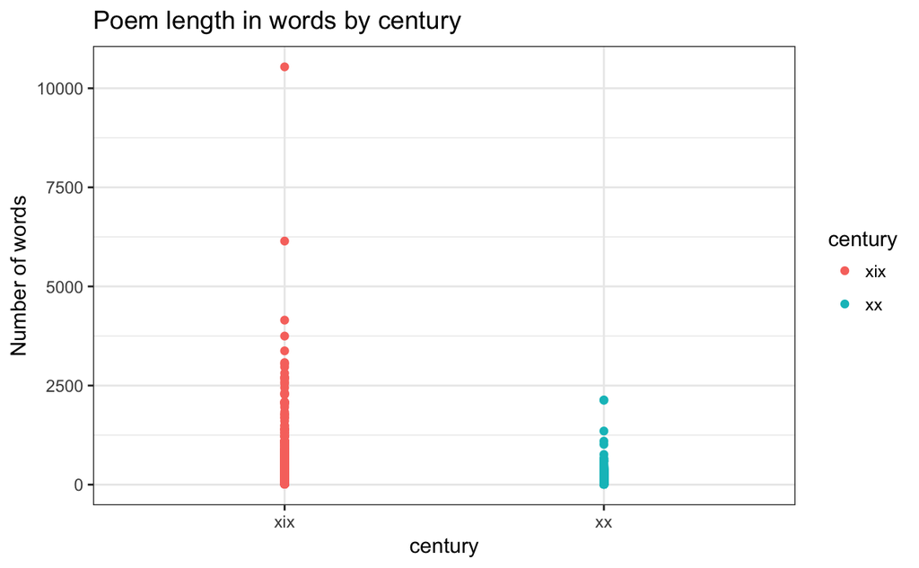

```r
poems %>%
  ggplot(aes(century, words))+
  geom_point(aes(color = century)) +
  labs(title = "Poem length in words by century") +
  ylab("Number of words") +
  theme_bw()
```

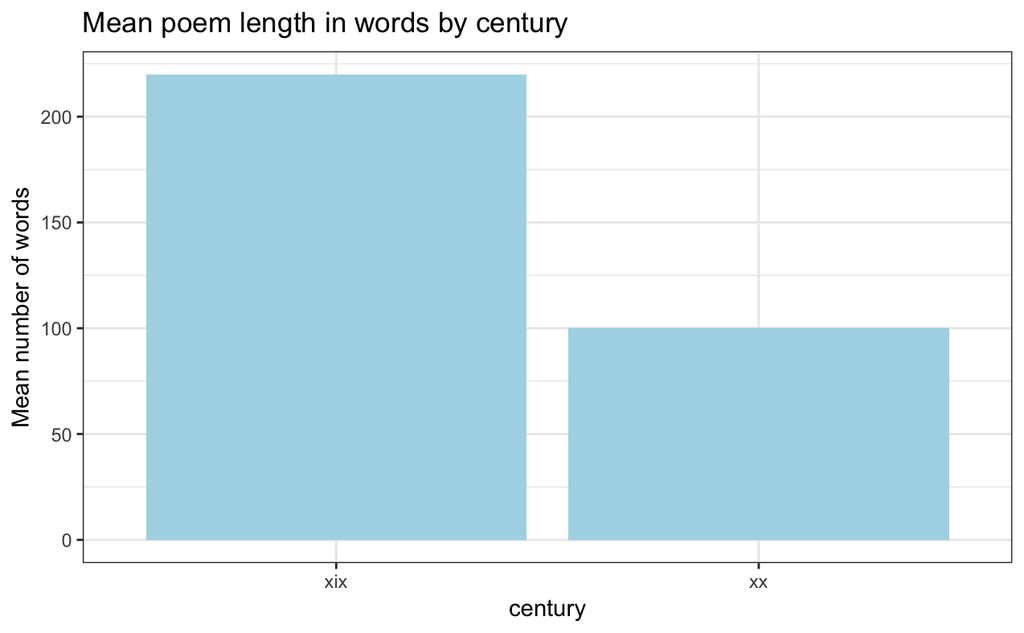

```r
poems %>%
  group_by(century) %>%
  summarise(mean_words = mean(words))  %>%
  ggplot(aes(x = century, y = mean_words)) +
  geom_col(fill = "lightblue") +
  labs(title = "Mean poem length in words by century") +
  ylab("Mean number of words") +
  theme_bw()
```

```r
NA
```

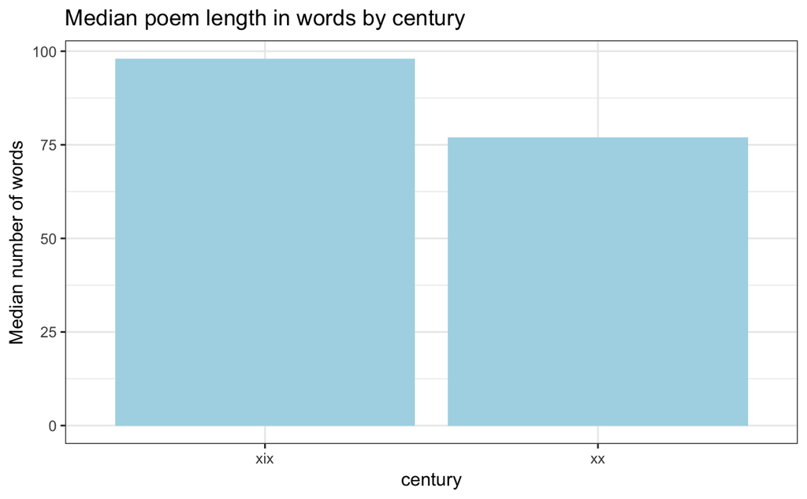

```r
poems %>%
  group_by(century) %>%
  summarise(median_words = median(words))  %>%
  ggplot(aes(x = century, y = median_words)) +
  geom_col(fill = "lightblue") +
  labs(title = "Median poem length in words by century") +
  ylab("Median number of words") +
  theme_bw()
```

How long are the lines in poems on average?

```r
poems %>%
  group_by(century) %>%
  summarise(mean_line_length = mean(words_per_line))
```

| century | mean_line_length |
| --- | --- |
| xix | 7.828122 |
| xx | 6.575275 |

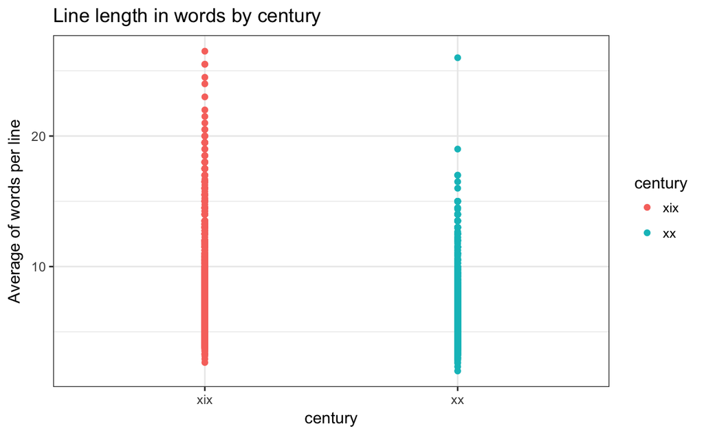

```r
poems %>%
  ggplot(aes(century, words_per_line))+
  geom_point(aes(color = century)) +
  labs(title = "Line length in words by century") +
  ylab("Average of words per line") +
  theme_bw()
```

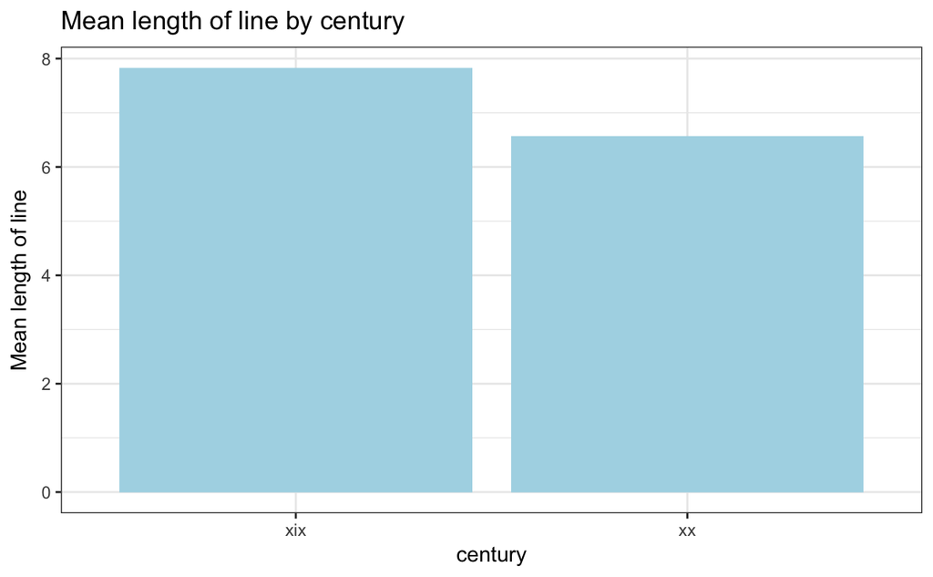

```r
poems %>%
  group_by(century) %>%
  summarise(mean_line_length = mean(words_per_line)) %>%
  ggplot(aes(x = century, y = mean_line_length)) +
  geom_col(fill = "lightblue") +
  labs(title = "Mean length of line by century") +
  ylab("Mean length of line") +
  theme_bw()
```

```r
NA
NA
```

Is the difference significant?

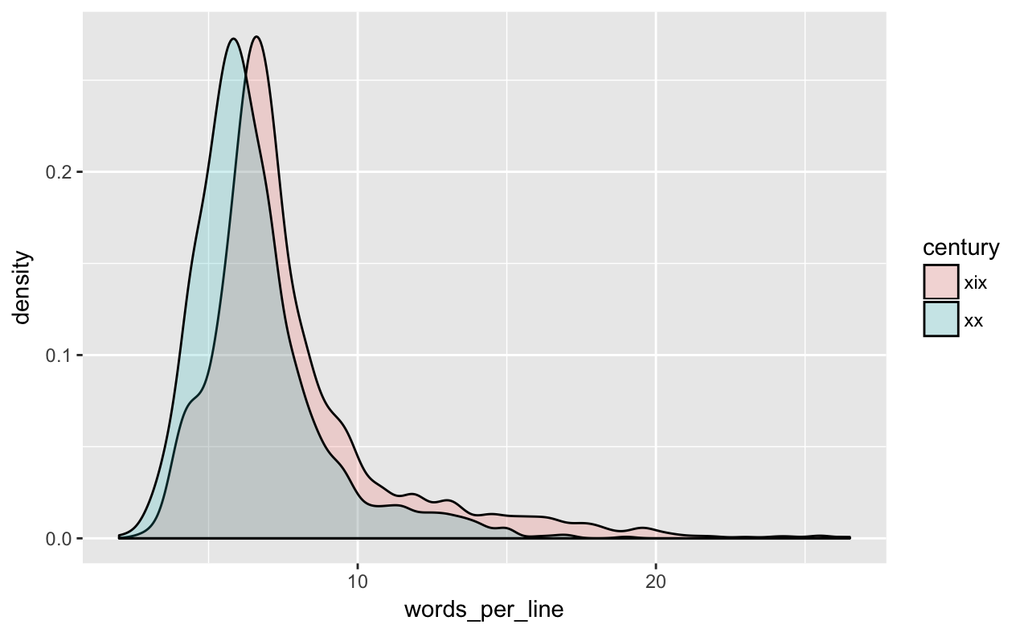

```r
poems %>%
  ggplot(aes(words_per_line, fill = century))+
  geom_density(alpha = 0.2)
```

```r
xix_cent$words_per_line <- round(xix_cent$words / xix_cent$rhymes, 2)
xx_cent_short$words_per_line <- round(xx_cent_short$words / xx_cent_short$rhymes, 2)
sd(xix_cent$words_per_line)
```

```
[1] 3.196447
```

```r
sd(xx_cent_short$words_per_line)
```

```
[1] 2.229734
```

The distributions don’t have equal variances. Let’s try Welch’s t-test.

```r
t.test(xix_cent$words_per_line, xx_cent_short$words_per_line, alternative = "two.sided", var.equal = FALSE)
```

```
    Welch Two Sample t-test

data:  xix_cent$words_per_line and xx_cent_short$words_per_line
t = 12.566, df = 2728.6, p-value < 2.2e-16
alternative hypothesis: true difference in means is not equal to 0
95 percent confidence interval:
 1.057348 1.448345
sample estimates:
mean of x mean of y
 7.828122  6.575275
```

I suppose we can say that 20th century poems have significantly shorter lines than 19th century poems.

Now what about rhyming verbs?

```r
head(poems)
```

|  | poem_id | century | words | nouns | adjectives | verbs | rhymes | rhyming_nouns | rhyming_adjectives | rhyming_verbs | words_per_line | percentage_verbs | percentage_rhyming_verbs |
| --- | --- | --- | --- | --- | --- | --- | --- | --- | --- | --- | --- | --- | --- |
| 1 | 0 | xix | 369 | 94 | 24 | 52 | 50 | 24 | 6 | 12 | 7.38 | 0.14 | 0.24 |
| 2 | 1 | xix | 116 | 30 | 10 | 8 | 16 | 9 | 1 | 2 | 7.25 | 0.07 | 0.12 |
| 3 | 2 | xix | 110 | 27 | 9 | 9 | 16 | 7 | 0 | 3 | 6.88 | 0.08 | 0.19 |
| 4 | 3 | xix | 625 | 151 | 39 | 97 | 114 | 47 | 6 | 36 | 5.48 | 0.16 | 0.32 |
| 5 | 4 | xix | 201 | 42 | 9 | 24 | 28 | 14 | 2 | 6 | 7.18 | 0.12 | 0.21 |
| 6 | 5 | xix | 70 | 13 | 3 | 12 | 12 | 8 | 1 | 2 | 5.83 | 0.17 | 0.17 |

```r
btest <- function(x, n, p) {binom.test(x, n, p, alternative=
                           "two.sided", conf.level = 0.95)$p.value}
poems$pval <- mapply(btest, poems$rhyming_verbs, poems$rhymes, poems$percentage_verbs)
poems$reject_null_hyp <- poems$pval < 0.05

head(poems)
```

|  | poem_id | century | words | nouns | adjectives | verbs | rhymes | rhyming_nouns | rhyming_adjectives | rhyming_verbs | words_per_line | percentage_verbs | percentage_rhyming_verbs | pval | reject_null_hyp |
| --- | --- | --- | --- | --- | --- | --- | --- | --- | --- | --- | --- | --- | --- | --- | --- |
| 1 | 0 | xix | 369 | 94 | 24 | 52 | 50 | 24 | 6 | 12 | 7.38 | 0.14 | 0.24 | 6.230526e-02 | FALSE |
| 2 | 1 | xix | 116 | 30 | 10 | 8 | 16 | 9 | 1 | 2 | 7.25 | 0.07 | 0.12 | 3.097632e-01 | FALSE |
| 3 | 2 | xix | 110 | 27 | 9 | 9 | 16 | 7 | 0 | 3 | 6.88 | 0.08 | 0.19 | 1.311496e-01 | FALSE |
| 4 | 3 | xix | 625 | 151 | 39 | 97 | 114 | 47 | 6 | 36 | 5.48 | 0.16 | 0.32 | 3.196492e-05 | TRUE |
| 5 | 4 | xix | 201 | 42 | 9 | 24 | 28 | 14 | 2 | 6 | 7.18 | 0.12 | 0.21 | 1.389657e-01 | FALSE |
| 6 | 5 | xix | 70 | 13 | 3 | 12 | 12 | 8 | 1 | 2 | 5.83 | 0.17 | 0.17 | 1.000000e+00 | FALSE |

```r
poems$fewer_rhyming_verbs <- poems$percentage_rhyming_verbs < poems$percentage_verbs
head(poems)
```

|  | poem_id | century | words | nouns | adjectives | verbs | rhymes | rhyming_nouns | rhyming_adjectives | rhyming_verbs | words_per_line | percentage_verbs | percentage_rhyming_verbs | pval | reject_null_hyp | fewer_rhyming_verbs |
| --- | --- | --- | --- | --- | --- | --- | --- | --- | --- | --- | --- | --- | --- | --- | --- | --- |
| 1 | 0 | xix | 369 | 94 | 24 | 52 | 50 | 24 | 6 | 12 | 7.38 | 0.14 | 0.24 | 6.230526e-02 | FALSE | FALSE |
| 2 | 1 | xix | 116 | 30 | 10 | 8 | 16 | 9 | 1 | 2 | 7.25 | 0.07 | 0.12 | 3.097632e-01 | FALSE | FALSE |
| 3 | 2 | xix | 110 | 27 | 9 | 9 | 16 | 7 | 0 | 3 | 6.88 | 0.08 | 0.19 | 1.311496e-01 | FALSE | FALSE |
| 4 | 3 | xix | 625 | 151 | 39 | 97 | 114 | 47 | 6 | 36 | 5.48 | 0.16 | 0.32 | 3.196492e-05 | TRUE | FALSE |
| 5 | 4 | xix | 201 | 42 | 9 | 24 | 28 | 14 | 2 | 6 | 7.18 | 0.12 | 0.21 | 1.389657e-01 | FALSE | FALSE |
| 6 | 5 | xix | 70 | 13 | 3 | 12 | 12 | 8 | 1 | 2 | 5.83 | 0.17 | 0.17 | 1.000000e+00 | FALSE | FALSE |

```r
significantly_fewer_r_verbs <- poems[(poems$fewer_rhyming_verbs == TRUE &
                                        poems$reject_null_hyp == TRUE), ]
significantly_fewer_r_verbs
```

|  | poem_id | century | words | nouns | adjectives | verbs | rhymes | rhyming_nouns | rhyming_adjectives | rhyming_verbs | words_per_line | percentage_verbs | percentage_rhyming_verbs | pval | reject_null_hyp | fewer_rhyming_verbs |
| --- | --- | --- | --- | --- | --- | --- | --- | --- | --- | --- | --- | --- | --- | --- | --- | --- |
| 488 | 487 | xix | 374 | 116 | 50 | 27 | 100 | 57 | 37 | 2 | 3.74 | 0.07 | 0.02 | 0.048196062 | TRUE | TRUE |
| 578 | 577 | xix | 1204 | 414 | 114 | 128 | 188 | 128 | 33 | 12 | 6.40 | 0.11 | 0.06 | 0.046463425 | TRUE | TRUE |
| 921 | 920 | xix | 177 | 51 | 13 | 23 | 32 | 22 | 3 | 0 | 5.53 | 0.13 | 0.00 | 0.017417686 | TRUE | TRUE |
| 1086 | 1085 | xix | 161 | 30 | 11 | 32 | 24 | 18 | 0 | 0 | 6.71 | 0.20 | 0.00 | 0.008510745 | TRUE | TRUE |
| 3538 | 3537 | xx | 217 | 62 | 13 | 25 | 34 | 26 | 4 | 0 | 6.38 | 0.12 | 0.00 | 0.029310432 | TRUE | TRUE |

```r
significantly_more_r_verbs <- poems[(poems$fewer_rhyming_verbs == FALSE &
                                        poems$reject_null_hyp == TRUE), ]
str(significantly_more_r_verbs)
```

```
'data.frame':   809 obs. of  16 variables:
 $ poem_id                 : int  3 10 12 13 15 18 27 29 31 36 ...
 $ century                 : Factor w/ 2 levels "xix","xx": 1 1 1 1 1 1 1 1 1 1 ...
 $ words                   : int  625 802 199 365 242 424 191 73 255 286 ...
 $ nouns                   : int  151 180 44 118 62 125 74 23 57 63 ...
 $ adjectives              : int  39 62 13 38 13 28 22 1 17 16 ...
 $ verbs                   : int  97 108 34 32 32 50 20 10 35 26 ...
 $ rhymes                  : int  114 114 28 54 36 64 32 8 36 36 ...
 $ rhyming_nouns           : int  47 50 13 31 18 31 19 1 19 17 ...
 $ rhyming_adjectives      : int  6 16 5 9 2 8 5 0 4 4 ...
 $ rhyming_verbs           : int  36 29 9 10 10 19 8 6 10 8 ...
 $ words_per_line          : num  5.48 7.04 7.11 6.76 6.72 6.62 5.97 9.12 7.08 7.94 ...
 $ percentage_verbs        : num  0.16 0.13 0.17 0.09 0.13 0.12 0.1 0.14 0.14 0.09 ...
 $ percentage_rhyming_verbs: num  0.32 0.25 0.32 0.19 0.28 0.3 0.25 0.75 0.28 0.22 ...
 $ pval                    : num  0.000032 0.000376 0.042711 0.027169 0.020742 ...
 $ reject_null_hyp         : logi  TRUE TRUE TRUE TRUE TRUE TRUE ...
 $ fewer_rhyming_verbs     : logi  FALSE FALSE FALSE FALSE FALSE FALSE ...
```

```r
poems %>%
  group_by(century, reject_null_hyp) %>%
  summarise(n())
```

| century | reject_null_hyp | n() |
| --- | --- | --- |
| xix | FALSE | 1017 |
| xix | TRUE | 511 |
| xx | FALSE | 1225 |
| xx | TRUE | 303 |

```r
NA
```

[figure not shown]

```r
contingency_table <- matrix(c(511, 1017, 303, 1225), nrow = 2, ncol = 2, byrow = TRUE)
dimnames(contingency_table) <- list(c("XIX century", "XX century"),
                                    c("more rhyming verbs", "no disproportion"))

contingency_table
```

```
            more rhyming verbs no disproportion
XIX century                511             1017
XX century                 303             1225
```

```r
fisher.test(contingency_table)
```

```
    Fisher's Exact Test for Count Data

data:  contingency_table
p-value < 2.2e-16
alternative hypothesis: true odds ratio is not equal to 1
95 percent confidence interval:
 1.717475 2.404006
sample estimates:
odds ratio
  2.030936
```

Apparently, we can conclude that the majority of poems in our sample do not show a disproporion of verbs in rhyming zones. Only 5 poems in the entire sample of over 3000 poems are significantly less likely to allow verbs in rhyming zones. Conversely, about a quarter of all poems in the sample are more show more verbs in the rhyming zone than in the poem in general. This preference is significantly more likely to occur in 19th century poems as opposed to 20th century poems.